# Analysis for Project

# Introduction

Back to top

Use this R Markdown to perform the main analysis for the project. I use this basically as a lab notebook. It contains the main analysis and a variety of sensitivity analysis. The code in this documents serves as a baseline for the eventual tables and figures that will go into the paper. At the same time it will serve as a record of all supplementary analyses performed.

# Data and Methods

# Analysis

First, I want to see the proportions of health insurance I’m working with.

```
IHS    None Private  Public
```

28195 421393 2896447 586594

```
    IHS        None     Private      Public
```

0.007169504 0.107153001 0.736516717 0.149160778

Covered NotCovered 3501893 430736

Covered NotCovered 0.8904712 0.1095288

```
  NH White       NH Black       Hispanic         NH API        NH AIAN
   2603952         390232         578405         239564          36213
```

NH Other/Multi 84263

```
  NH White       NH Black       Hispanic         NH API        NH AIAN
```

0.662140263 0.099229294 0.147078456 0.060917010 0.009208344 NH Other/Multi 0.021426633

```
                    Estimate Std. Error  z value Pr(>|z|)
```

(Intercept) age 1.31468100 0.01909152 (Intercept) age 3.723563 1.019275

The age model shows that a one year increase in age is associated with an increase in the predicated probability of healthcare coverage.

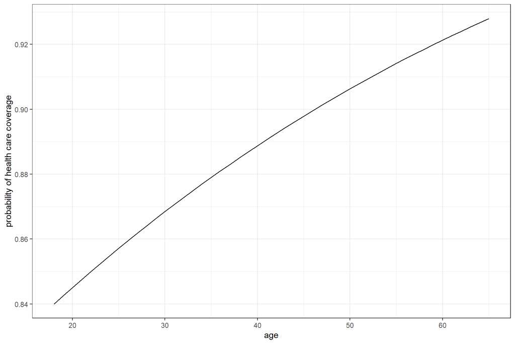

**Why are the numbers different between age graph + model?

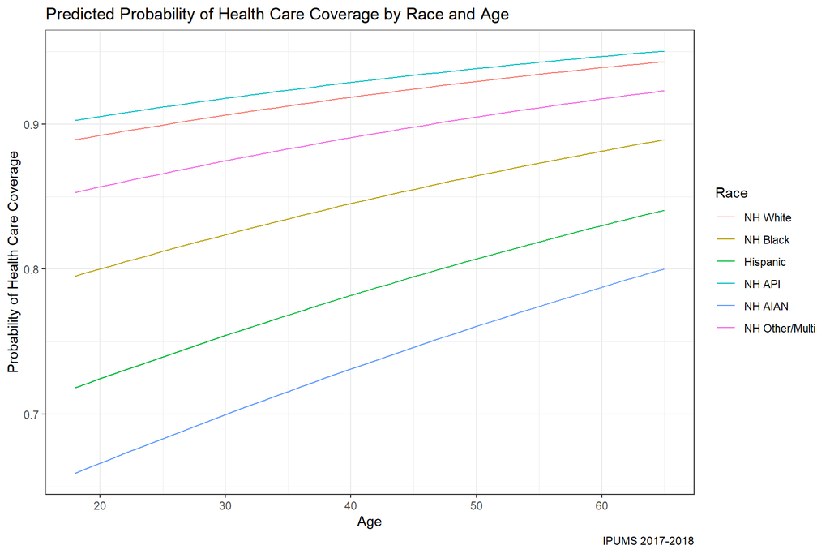

(Intercept) age racecomboNH Black 6.0747317 1.0156158 0.4835139 racecomboHispanic racecomboNH API racecomboNH AIAN 0.3173805 1.1558170 0.2409097 racecomboNH Other/Multi 0.7221836

The combined age and race model still shows an increase in the predicted probability of health care coverage as age increases, but has vastly differenct effects for race.

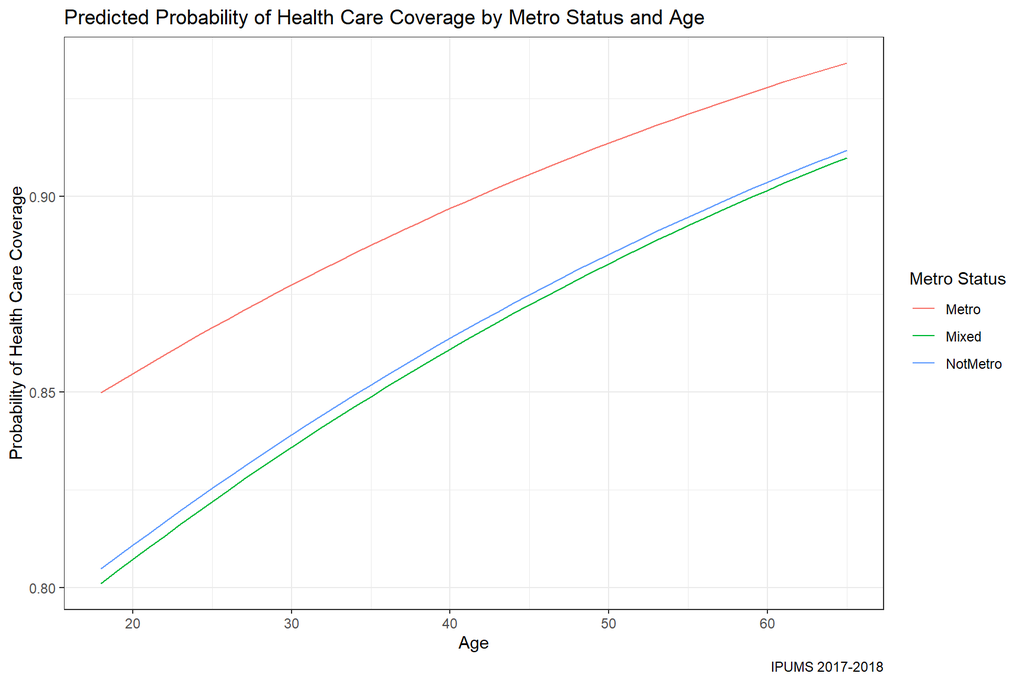

(Intercept) age metrosMixed metrosNotMetro 3.9783126 1.0197721 0.7115937 0.7284631

The metro status and age model still shows an increase in the predicted probability of health care coverage as age increases, but mixed metro and non-metro status and non-metro status have far a far lower predicted probability of having health care coverage.

```
                                   Estimate Std. Error  z value Pr(>|z|)
```

(Intercept) -2.427 0.003 -709.618 0.000 I(age - 42) -0.019 0.000 -145.862 0.000 I((age - 42)^2) -0.001 0.000 -103.554 0.000 metrosMixed 0.507 0.006 88.699 0.000 metrosNotMetro 0.490 0.007 75.155 0.000 racecomboNH Black 0.740 0.006 124.349 0.000 racecomboHispanic 1.246 0.005 276.590 0.000 racecomboNH API -0.041 0.009 -4.627 0.000 racecomboNH AIAN 1.306 0.021 62.269 0.000 racecomboNH Other/Multi 0.333 0.013 25.350 0.000 metrosMixed:racecomboNH Black 0.193 0.014 14.047 0.000 metrosNotMetro:racecomboNH Black 0.325 0.017 19.103 0.000 metrosMixed:racecomboHispanic 0.024 0.013 1.805 0.071 metrosNotMetro:racecomboHispanic -0.058 0.016 -3.500 0.000 metrosMixed:racecomboNH API 0.096 0.038 2.498 0.012 metrosNotMetro:racecomboNH API 0.220 0.048 4.612 0.000 metrosMixed:racecomboNH AIAN -0.038 0.030 -1.251 0.211 metrosNotMetro:racecomboNH AIAN -0.067 0.030 -2.260 0.024 metrosMixed:racecomboNH Other/Multi 0.242 0.030 8.128 0.000 metrosNotMetro:racecomboNH Other/Multi 0.159 0.036 4.372 0.000 (Intercept) I(age - 42) 0.0882968 0.9811529 I((age - 42)^2) metrosMixed 0.9989550 1.6603140 metrosNotMetro racecomboNH Black 1.6324872 2.0968630 racecomboHispanic racecomboNH API 3.4753594 0.9602433 racecomboNH AIAN racecomboNH Other/Multi 3.6902416 1.3948855 metrosMixed:racecomboNH Black metrosNotMetro:racecomboNH Black 1.2126951 1.3842467 metrosMixed:racecomboHispanic metrosNotMetro:racecomboHispanic 1.0246080 0.9439176 metrosMixed:racecomboNH API metrosNotMetro:racecomboNH API 1.1003454 1.2464382 metrosMixed:racecomboNH AIAN metrosNotMetro:racecomboNH AIAN 0.9626232 0.9349788 metrosMixed:racecomboNH Other/Multi metrosNotMetro:racecomboNH Other/Multi 1.2735963 1.1724062 This a very complex model. [1] -29675.59 [1] -124111.9 [1] -153787.5